# Mushrooms4All

Abraham Carrera, Miguel Magaña

## Introducción

Mushrooms4all es una empresa encargada de fomentar la venta y recolección de setas. Uno de los problemas del sector es la existencia de setas no aptas para el consumo. Por suerte, disponen de una gran base de datos con información sobre distintas características de las setas y su aptitud (o no) para el consumo humano.

Sin embargo, les gustaría ser capaces de predecir a partir de la base de conocimiento si una seta desconocida es o no venenosa simplemente identificando sus características. Para ello solicitan la creación de una aplicación que mediante la creación de un modelo de los datos disponibles lleve a cabo dicha predicción.

## Entendimiento y preparación de los datos

### Descripción de los datos

En primer lugar, tras recibir de manos de Mushrooms4All el dataset, lo importamos así como el conjunto de librerías que vamos a utilizar.

```r
suppressMessages(library(caret))
suppressMessages(library(ggplot2))
suppressMessages(library(dplyr))
suppressMessages(library(gridExtra))
suppressMessages(library(gmodels))
suppressMessages(library(ggparallel))
suppressMessages(library(rpart.plot))
suppressMessages(library(sqldf))
suppressMessages(library(tidyverse))
suppressMessages(library(vcd))
suppressMessages(library(GoodmanKruskal))
suppressMessages(library(dismo))
suppressMessages(library(MLmetrics))
suppressMessages(library(ROCR))
suppressMessages(library(e1071))
suppressMessages(library(randomForest))
setas<-read.csv("../inputs/mushrooms.csv", header = TRUE)
```

A continuación se analiza la apariencia de nuestros datos:

- Consisten en 8124 observaciones de 23 variables
- Todas las variables son categoricas con letras como valores
- Las variables son las siguientes:
- cap-shape: forma del gorro.
- cap-surface: superficie del gorro.
- cap-color: color del gorro.
- bruises: si tiene manchas.
- odor: olor.
- gill-attachment: unión de las agallas.
- gill-spacing: espacio entre las agallas.
- gill-size: tamaño de las agallas.
- gill-color: color de las agallas.
- stalk-shape: forma del tallo.
- stalk-root: raíz del tallo.
- stalk-surface-above-ring: tipo de superficie sobre el anillo.
- stalk-surface-below-ring: tipo de superficie por debajo del anillo.
- stalk-color-above-ring: color sobre el anillo.
- stalk-color-below-ring: color bajo el anillo.
- veil-type: tipo de velo.
- veil-color: color del velo.
- ring-number: número de anillos.
- ring-type: tipo de anillo.
- spore-print-color:color de las espras.
- population: tamaño de la población.
- habitat: lugar en el que crecen.

```r
head(setas)
```

|  | class | cap.shape | cap.surface | cap.color | bruises | odor | gill.attachment | gill.spacing | gill.size | gill.color | stalk.shape | stalk.root | stalk.surface.above.ring | stalk.surface.below.ring | stalk.color.above.ring | stalk.color.below.ring | veil.type | veil.color | ring.number | ring.type | spore.print.color | population | habitat |
| --- | --- | --- | --- | --- | --- | --- | --- | --- | --- | --- | --- | --- | --- | --- | --- | --- | --- | --- | --- | --- | --- | --- | --- |
| 1 | p | s | f | g | t | p | f | d | n | k | e | e | s | s | c | c | p | w | t | p | k | n | u |
| 2 | e | x | g | y | t | a | d | c | b | k | e | c | y | y | e | e | p | w | o | p | u | a | p |
| 3 | e | k | s | n | t | l | f | w | b | n | t | c | s | k | b | b | p | w | o | p | n | v | g |
| 4 | p | b | y | w | t | y | f | c | n | e | t | e | s | k | w | g | p | w | b | n | k | s | u |
| 5 | e | b | s | g | f | n | n | c | b | o | t | b | s | s | w | e | p | w | b | z | w | a | g |
| 6 | e | k | s | y | f | a | f | w | n | n | t | z | s | s | b | b | p | w | o | p | k | n | p |

```r
dim(setas)
```

```
[1] 8124   23
```

```r
glimpse(setas)
```

```
Observations: 8,124
Variables: 23
$ class                    <fct> p, e, e, p, e, e, e, e, p, e, e, e, e, p, e, e, e, p, p, p, e, p, e, e, e, p, e, e, e, e, e, p, e, e, e, e, e, ...
$ cap.shape                <fct> s, x, k, b, b, k, f, b, s, b, x, c, b, x, s, s, f, x, b, s, c, x, c, b, b, f, f, k, b, f, b, x, k, f, b, x, s, ...
$ cap.surface              <fct> f, g, s, y, s, s, f, y, y, s, s, g, g, g, f, g, f, f, y, g, s, y, y, y, s, g, y, y, s, s, s, y, y, y, g, s, f, ...
$ cap.color                <fct> g, y, n, w, g, y, w, w, y, y, r, y, c, w, e, r, w, n, w, y, p, g, y, w, w, r, e, u, r, y, p, w, r, e, n, c, g, ...
$ bruises                  <fct> t, t, t, t, f, f, t, t, f, t, t, t, t, t, t, t, t, t, f, t, f, t, t, t, f, t, t, t, f, t, t, t, t, t, t, f, f, ...
$ odor                     <fct> p, a, l, y, n, a, a, l, p, a, l, p, a, c, m, n, y, p, y, m, a, y, l, a, l, c, a, l, n, a, l, c, f, l, l, l, n, ...
$ gill.attachment          <fct> f, d, f, f, n, f, a, f, f, d, n, d, f, f, a, d, a, f, n, d, n, d, d, a, f, d, a, f, f, f, f, f, f, f, f, f, a, ...
$ gill.spacing             <fct> d, c, w, c, c, w, c, c, d, c, d, w, c, d, w, w, w, c, c, c, w, c, w, w, c, d, c, w, c, c, c, d, w, c, c, d, c, ...
$ gill.size                <fct> n, b, b, n, b, n, b, b, n, b, n, b, b, n, b, n, b, b, n, n, n, n, b, b, b, n, b, b, n, n, b, b, b, b, b, n, b, ...
$ gill.color               <fct> k, k, n, e, o, n, g, r, b, g, b, n, k, r, n, k, k, p, n, h, p, h, p, w, o, b, n, w, k, h, g, u, w, e, n, u, k, ...
$ stalk.shape              <fct> e, e, t, t, t, t, e, t, t, e, e, e, e, e, e, e, e, e, t, e, t, e, e, e, t, e, e, e, t, t, e, e, e, e, e, t, e, ...
$ stalk.root               <fct> e, c, c, e, b, z, c, c, u, c, u, c, b, r, r, z, e, c, b, e, c, e, c, z, b, e, e, c, e, e, r, u, z, r, b, u, e, ...
$ stalk.surface.above.ring <fct> s, y, s, s, s, s, s, s, s, y, s, y, y, y, f, s, f, s, s, s, s, y, y, s, s, y, f, y, s, k, k, s, s, f, s, s, f, ...
$ stalk.surface.below.ring <fct> s, y, k, k, s, s, f, s, s, y, s, y, s, y, f, y, f, f, s, s, s, y, s, f, s, y, s, s, s, s, k, y, y, f, s, s, f, ...
$ stalk.color.above.ring   <fct> c, e, b, w, w, b, w, y, w, w, w, w, n, w, p, o, g, b, g, w, w, w, b, w, g, c, n, b, e, g, c, g, o, w, n, y, w, ...
$ stalk.color.below.ring   <fct> c, e, b, g, e, b, w, y, w, o, w, w, w, c, w, o, g, w, g, w, w, g, w, w, g, w, w, w, w, g, w, g, w, w, n, y, g, ...
$ veil.type                <fct> p, p, p, p, p, p, p, u, p, p, u, p, p, p, p, p, p, p, p, p, u, p, p, p, u, p, p, p, p, p, p, p, p, p, p, p, p, ...
$ veil.color               <fct> w, w, w, w, w, w, w, w, y, w, y, w, o, o, w, o, n, w, w, w, w, o, w, n, w, w, n, o, y, w, w, w, w, w, o, w, n, ...
$ ring.number              <fct> t, o, o, b, b, o, o, t, t, o, o, o, o, o, t, o, o, o, b, b, o, o, b, o, o, t, o, o, o, o, t, o, o, o, b, t, b, ...
$ ring.type                <fct> p, p, p, n, z, p, p, p, p, p, s, f, f, p, e, l, e, e, s, p, s, l, p, p, n, f, p, p, p, p, n, p, f, p, l, p, p, ...
$ spore.print.color        <fct> k, u, n, k, w, k, w, y, b, k, b, w, n, b, k, n, n, k, h, u, n, n, u, r, k, n, k, n, k, w, n, n, r, n, n, y, k, ...
$ population               <fct> n, a, v, s, a, n, n, y, v, s, n, s, a, v, a, v, s, c, s, s, c, s, s, v, a, n, s, v, a, v, y, s, v, s, a, n, a, ...
$ habitat                  <fct> u, p, g, u, g, p, m, w, w, g, g, g, d, g, g, p, g, g, g, w, m, d, d, d, l, w, g, m, u, l, p, l, u, p, m, u, u, ...
```

Numero de niveles de cada variable:

```r
number_class <- function(x){
  x <- length(levels(x))
}
x <- setas %>% map_dbl(function(.x) number_class(.x)) %>% as_tibble() %>%
  rownames_to_column() %>% arrange(desc(value))
colnames(x) <- c("Variable name", "Number of levels")
print(x)
```

| Variable name | Number of levels |
| --- | --- |
| gill.color | 12 |
| cap.color | 10 |
| odor | 9 |
| stalk.color.above.ring | 9 |
| stalk.color.below.ring | 9 |
| spore.print.color | 9 |
| ring.type | 8 |
| stalk.root | 7 |
| habitat | 7 |
| cap.shape | 6 |

[output cut: 13 more lines]

### Verificación de la calidad de los datos

Se observa que los valores de las variables se definen utilizando una sola letra, lo que los convierte en ilegibles para el observador humano. Por ello se llevará a cabo un procedimiento de formateo de los datos (ver apartado siguiente).

Se comprobó la existencia de missing values, no encontrando ninguno.

```r
map_dbl(setas, function(.x) {sum(is.na(.x))})
```

```
                   class                cap.shape              cap.surface                cap.color                  bruises
                       0                        0                        0                        0                        0
                    odor          gill.attachment             gill.spacing                gill.size               gill.color
                       0                        0                        0                        0                        0
             stalk.shape               stalk.root stalk.surface.above.ring stalk.surface.below.ring   stalk.color.above.ring
                       0                        0                        0                        0                        0
  stalk.color.below.ring                veil.type               veil.color              ring.number                ring.type
                       0                        0                        0                        0                        0
       spore.print.color               population                  habitat
                       0                        0                        0
```

### Formateo de los datos*

*Aunque según el CRISP-DM esta tarea correspondería a la fase de preparación de los datos y aunque aún no se ha finalizado el reporte de la fase de entendimiento, hemos decidido incluirla en este apartado para lograr gráficos con nombres de valor de variables significativos.

Comenzamos renombrando los nombres de las variables para adaptarlos al formato Snake Case y dotar algunos de ellos de más significado como el caso de la antigua “class” nueva “edibility”.

```r
colnames(setas) <- c("edibility", "cap_shape", "cap_surface",
                        "cap_color", "bruises", "odor",
                        "gill_attachement", "gill_spacing", "gill_size",
                        "gill_color", "stalk_shape", "stalk_root",
                        "stalk_surface_above_ring", "stalk_surface_below_ring", "stalk_color_above_ring",
                        "stalk_color_below_ring", "veil_type", "veil_color",
                        "ring_number", "ring_type", "spore_print_color",
                        "population", "habitat")
```

Renombramos los también valores de cada una de las variables a sus significados extraidos de la explicación del dataset.

```r
#setas <- setas %>% map_df(function(.x) as.factor(.x))
levels(setas$edibility) <- c("edible", "poisonous")
levels(setas$cap_shape) <- c("bell", "conical", "flat", "knobbed", "sunken", "convex")
levels(setas$cap_color) <- c("buff", "cinnamon", "red", "gray", "brown", "pink",
                                "green", "purple", "white", "yellow")
levels(setas$cap_surface) <- c("fibrous", "grooves", "scaly", "smooth")
levels(setas$bruises) <- c("no", "yes")
levels(setas$odor) <- c("almond", "creosote", "foul", "anise", "musty", "none", "pungent", "spicy", "fishy")
levels(setas$gill_attachement) <- c("attached","descending", "free","notched")
levels(setas$gill_spacing) <- c("close", "crowded","distant")
levels(setas$gill_size) <- c("broad", "narrow")
levels(setas$gill_color) <- c("buff", "red", "gray", "chocolate", "black", "brown", "orange",
                                 "pink", "green", "purple", "white", "yellow")
levels(setas$stalk_shape) <- c("enlarging", "tapering")
levels(setas$stalk_root) <- c("bulbous", "club", "cup", "equal","rhizomorphs", "rooted", "missing")
levels(setas$stalk_surface_above_ring) <- c("fibrous", "silky", "smooth", "scaly")
levels(setas$stalk_surface_below_ring) <- c("fibrous", "silky", "smooth", "scaly")
levels(setas$stalk_color_above_ring) <- c("buff", "cinnamon", "red", "gray", "brown", "pink",
                                             "green", "purple", "white", "yellow")
levels(setas$stalk_color_below_ring) <- c("buff", "cinnamon", "red", "gray", "brown", "pink",
                                             "green", "purple", "white", "yellow")
levels(setas$veil_type) <- c("partial", "universal")
levels(setas$veil_color) <- c("brown", "orange", "white", "yellow")
# En el dataset pone B o y T y en la despcripcion None one and two.
levels(setas$ring_number) <- c("b","none", "one", "two")
levels(setas$ring_type) <- c("cobwebby","evanescent", "flaring", "large", "none", "pendant", "sheathing", "zone")
levels(setas$spore_print_color) <- c("buff", "chocolate", "black", "brown", "orange",
                                        "green", "purple", "white", "yellow")
levels(setas$population) <- c("abundant", "clustered", "numerous", "scattered", "several", "solitary")
levels(setas$habitat) <- c("wood", "grasses", "leaves", "meadows", "paths", "urban", "waste")
glimpse(setas)
```

```
Observations: 8,124
Variables: 23
$ edibility                <fct> poisonous, edible, edible, poisonous, edible, edible, edible, edible, poisonous, edible, edible, edible, edible...
$ cap_shape                <fct> sunken, convex, knobbed, bell, bell, knobbed, flat, bell, sunken, bell, convex, conical, bell, convex, sunken, ...
$ cap_surface              <fct> fibrous, grooves, scaly, smooth, scaly, scaly, fibrous, smooth, smooth, scaly, scaly, grooves, grooves, grooves...
$ cap_color                <fct> gray, yellow, brown, white, gray, yellow, white, white, yellow, yellow, green, yellow, cinnamon, white, red, gr...
$ bruises                  <fct> yes, yes, yes, yes, no, no, yes, yes, no, yes, yes, yes, yes, yes, yes, yes, yes, yes, no, yes, no, yes, yes, y...
$ odor                     <fct> pungent, almond, anise, fishy, none, almond, almond, anise, pungent, almond, anise, pungent, almond, creosote, ...
$ gill_attachement         <fct> free, descending, free, free, notched, free, attached, free, free, descending, notched, descending, free, free,...
$ gill_spacing             <fct> crowded, close, distant, close, close, distant, close, close, crowded, close, crowded, distant, close, crowded,...
$ gill_size                <fct> narrow, broad, broad, narrow, broad, narrow, broad, broad, narrow, broad, narrow, broad, broad, narrow, broad, ...
$ gill_color               <fct> black, black, brown, red, orange, brown, gray, green, buff, gray, buff, brown, black, green, brown, black, blac...
$ stalk_shape              <fct> enlarging, enlarging, tapering, tapering, tapering, tapering, enlarging, tapering, tapering, enlarging, enlargi...
$ stalk_root               <fct> equal, cup, cup, equal, club, missing, cup, cup, rooted, cup, rooted, cup, club, rhizomorphs, rhizomorphs, miss...
$ stalk_surface_above_ring <fct> smooth, scaly, smooth, smooth, smooth, smooth, smooth, smooth, smooth, scaly, smooth, scaly, scaly, scaly, fibr...
$ stalk_surface_below_ring <fct> smooth, scaly, silky, silky, smooth, smooth, fibrous, smooth, smooth, scaly, smooth, scaly, smooth, scaly, fibr...
$ stalk_color_above_ring   <fct> cinnamon, red, buff, purple, purple, buff, purple, white, purple, purple, purple, purple, brown, purple, green,...
$ stalk_color_below_ring   <fct> cinnamon, red, buff, gray, red, buff, purple, white, purple, pink, purple, purple, purple, cinnamon, purple, pi...
$ veil_type                <fct> partial, partial, partial, partial, partial, partial, partial, universal, partial, partial, universal, partial,...
$ veil_color               <fct> white, white, white, white, white, white, white, white, yellow, white, yellow, white, orange, orange, white, or...
$ ring_number              <fct> two, one, one, b, b, one, one, two, two, one, one, one, one, one, two, one, one, one, b, b, one, one, b, one, o...
$ ring_type                <fct> pendant, pendant, pendant, none, zone, pendant, pendant, pendant, pendant, pendant, sheathing, flaring, flaring...
$ spore_print_color        <fct> black, purple, brown, black, white, black, white, yellow, buff, black, buff, white, brown, buff, black, brown, ...
$ population               <fct> numerous, abundant, several, scattered, abundant, numerous, numerous, solitary, several, scattered, numerous, s...
$ habitat                  <fct> urban, paths, grasses, urban, grasses, paths, meadows, waste, waste, grasses, grasses, grasses, wood, grasses, ...
```

### Exploración de los datos

Analizamos la distribución de cada una de las variables que conforman el dataset con una serie de gráficos de barras. Los hechos relevantes que se extraen son los siguientes:

- Existe un número ligeramente mayor de setas comestibles que venenosas en el conjunto de datos.
- En la forma del gorro destacan ‘flat’ y ‘convex’.
- En el olor destacan ‘foul’ y ‘none’.
- Una gran mayoría tiene el valor ‘free’ para ‘Gill attachement’ y ‘Close para Gill spacing’.
- Destaca la raíz con forma ’club’y el color morado tanto por encima como por debajo del anillo.
- Una gran mayoría tiene velo parcial y blanco.

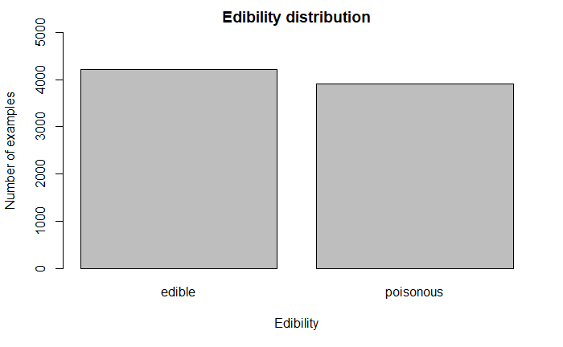

```r
barplot(table(setas$edibility), xlab = "Edibility", ylab = "Number of examples",
        main = "Edibility distribution",ylim=c(0,5000))
```

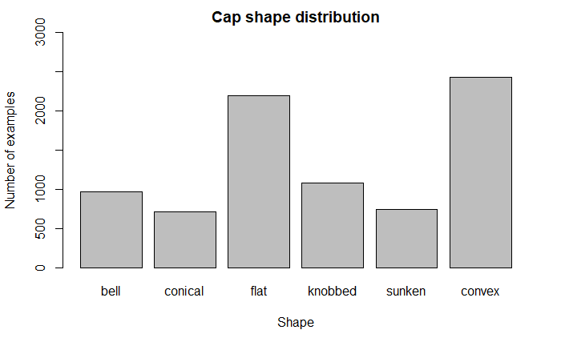

```r
barplot(table(setas$cap_shape), xlab = "Shape", ylab = "Number of examples",
        main = "Cap shape distribution",ylim=c(0,3000))
```

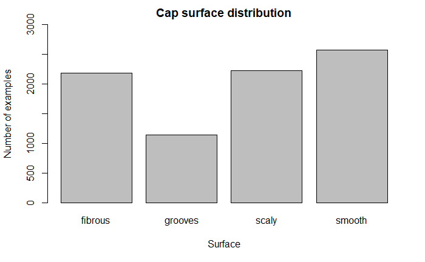

```r
barplot(table(setas$cap_surface), xlab = "Surface", ylab = "Number of examples",
        main = "Cap surface distribution",ylim=c(0,3000))
```

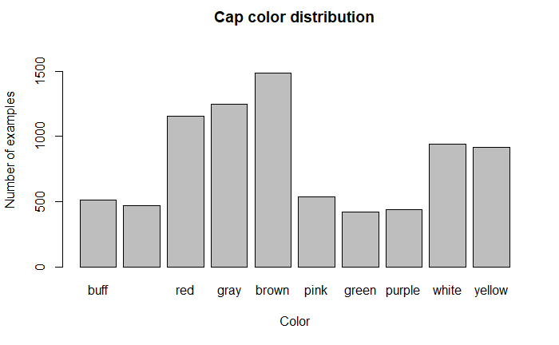

```r
barplot(table(setas$cap_color), xlab = "Color", ylab = "Number of examples",
        main = "Cap color distribution",ylim=c(0,1800))
```

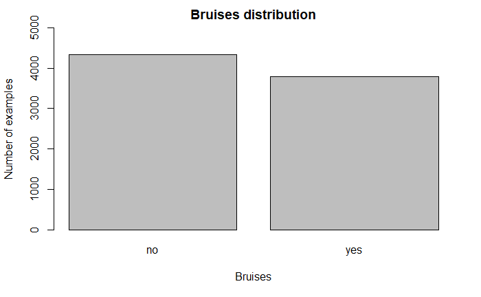

```r
barplot(table(setas$bruises), xlab = "Bruises", ylab = "Number of examples",
        main = "Bruises distribution",ylim=c(0,5000))
```

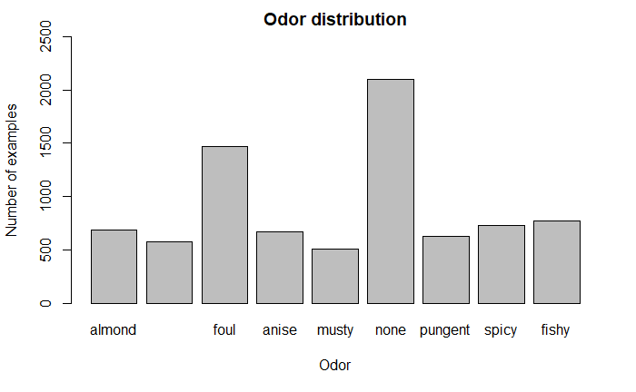

```r
barplot(table(setas$odor), xlab = "Odor", ylab = "Number of examples",
        main = "Odor distribution",ylim=c(0,2500))
```

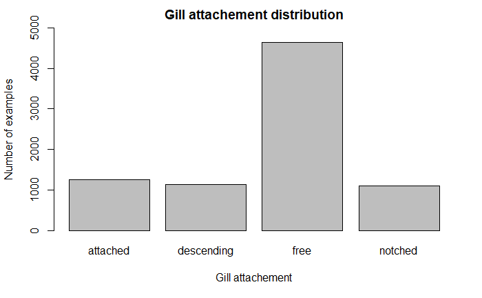

```r
barplot(table(setas$gill_attachement), xlab = "Gill attachement", ylab = "Number of examples",
        main = "Gill attachement distribution",ylim=c(0,5000))
```

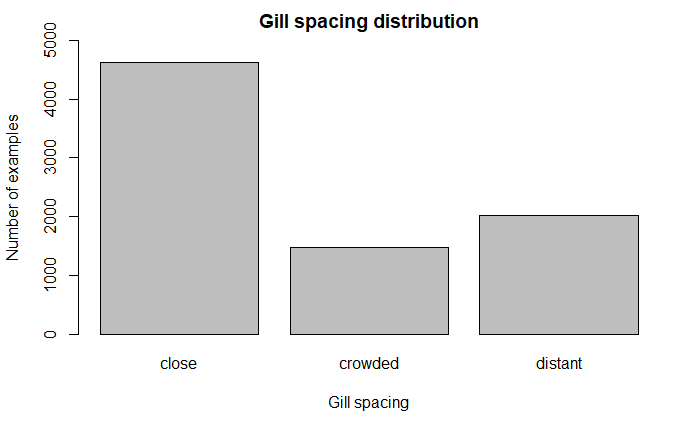

```r
barplot(table(setas$gill_spacing), xlab = "Gill spacing", ylab = "Number of examples",
        main = "Gill spacing distribution",ylim=c(0,5000))
```

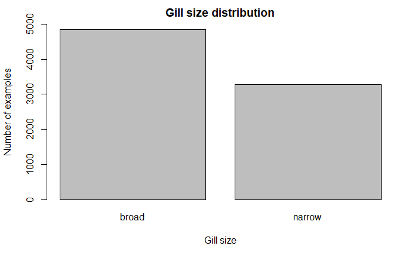

```r
barplot(table(setas$gill_size), xlab = "Gill size", ylab = "Number of examples",
        main = "Gill size distribution",ylim=c(0,5000))
```

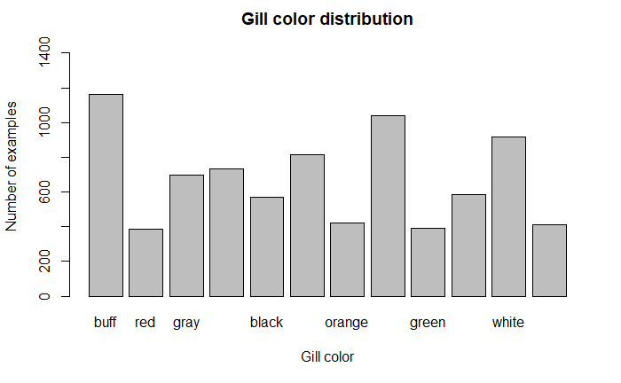

```r
barplot(table(setas$gill_color), xlab = "Gill color", ylab = "Number of examples",
        main = "Gill color distribution",ylim=c(0,1500))
```

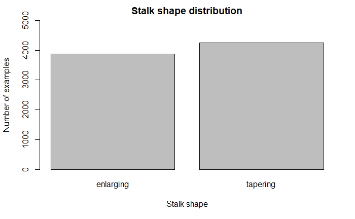

```r
barplot(table(setas$stalk_shape), xlab = "Stalk shape", ylab = "Number of examples",
        main = "Stalk shape distribution",ylim=c(0,5000))
```

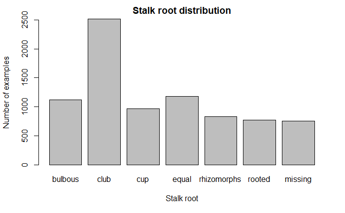

```r
barplot(table(setas$stalk_root), xlab = "Stalk root", ylab = "Number of examples",
        main = "Stalk root distribution",ylim=c(0,2500))
```

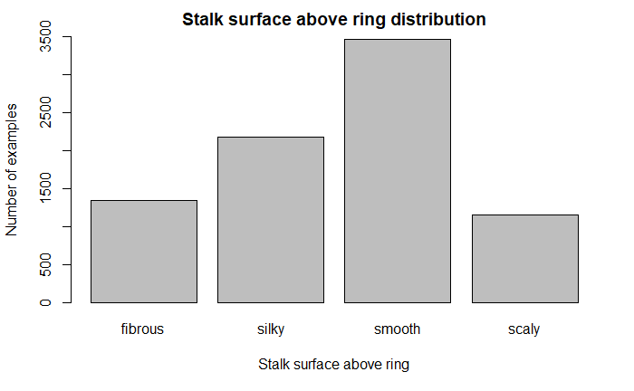

```r
barplot(table(setas$stalk_surface_above_ring), xlab = "Stalk surface above ring", ylab = "Number of examples",
        main = "Stalk surface above ring distribution",ylim=c(0,3500))
```

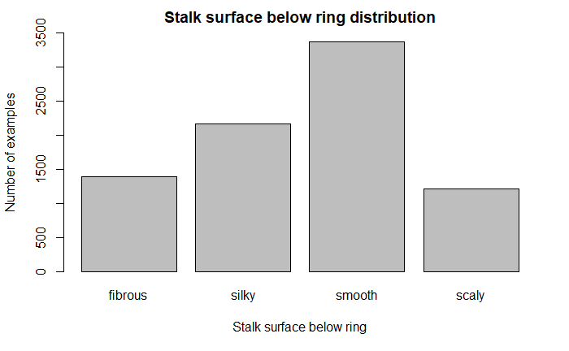

```r
barplot(table(setas$stalk_surface_below_ring), xlab = "Stalk surface below ring", ylab = "Number of examples",
        main = "Stalk surface below ring distribution",ylim=c(0,3500))
```

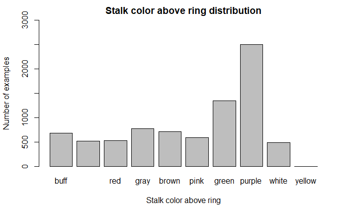

```r
barplot(table(setas$stalk_color_above_ring), xlab = "Stalk color above ring", ylab = "Number of examples",
        main = "Stalk color above ring distribution",ylim=c(0,3000))
```

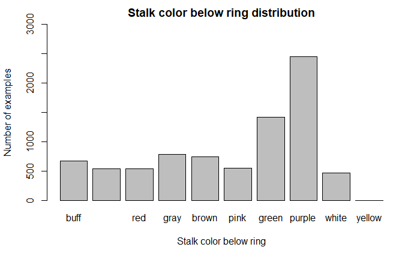

```r
barplot(table(setas$stalk_color_below_ring), xlab = "Stalk color below ring", ylab = "Number of examples",
        main = "Stalk color below ring distribution",ylim=c(0,3000))
```

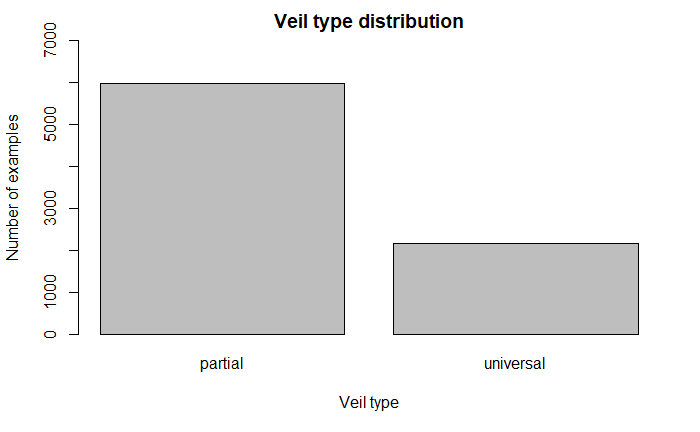

```r
barplot(table(setas$veil_type), xlab = "Veil type", ylab = "Number of examples",
        main = "Veil type distribution",ylim=c(0,7000))
```

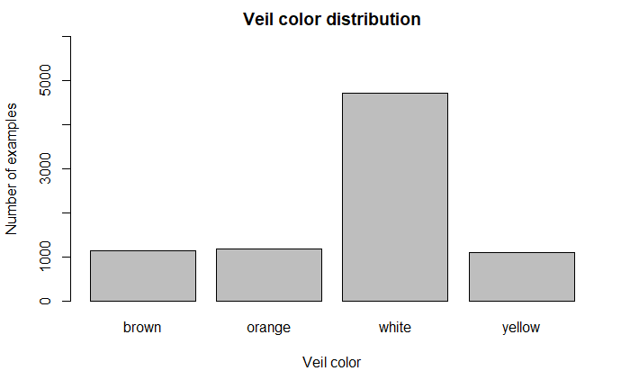

```r
barplot(table(setas$veil_color), xlab = "Veil color", ylab = "Number of examples",
        main = "Veil color distribution",ylim=c(0,6000))
```

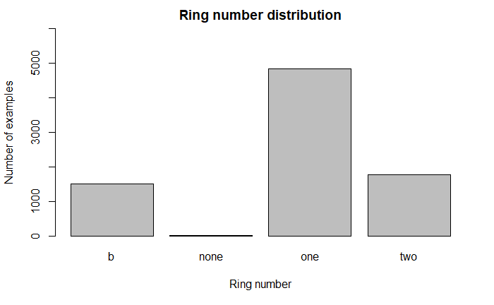

```r
barplot(table(setas$ring_number), xlab = "Ring number", ylab = "Number of examples",
        main = "Ring number distribution",ylim=c(0,6000))
```

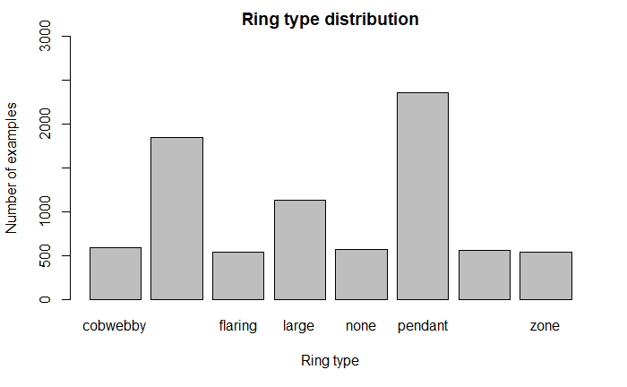

```r
barplot(table(setas$ring_type), xlab = "Ring type", ylab = "Number of examples",
        main = "Ring type distribution",ylim=c(0,3000))
```

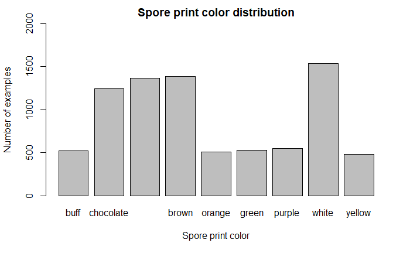

```r
barplot(table(setas$spore_print_color), xlab = "Spore print color", ylab = "Number of examples",
        main = "Spore print color distribution",ylim=c(0,2000))
```

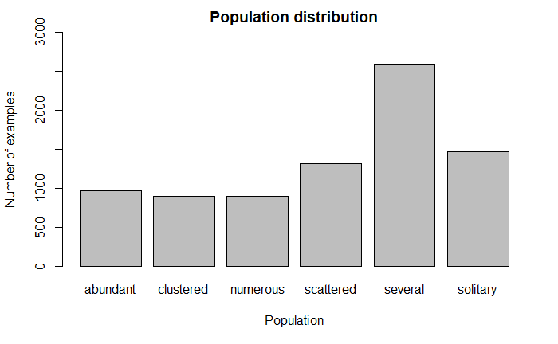

```r
barplot(table(setas$population), xlab = "Population", ylab = "Number of examples",
        main = "Population distribution",ylim=c(0,3000))
```

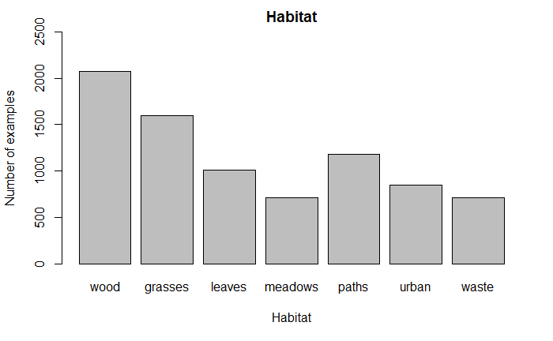

```r
barplot(table(setas$habitat), xlab = "Habitat", ylab = "Number of examples",
        main = "Habitat",ylim=c(0,2500))
```

A continuación evaluamos la distribucion de cada variable con respecto a la variable respuesta para ver si existen indicios de que alguna variable parece determinante a la hora de decidir si una seta es venenosa o no. A la vista de los resultados, las principales conclusiones extraídas han sido las siguientes:

- Las setas con olor ‘none’ parecen mucho más tendentes a ser comestibles y las que tienen olor ‘foul’ a ser venenosas.
- Las setas con el anillo grande parecen tender a ser más venenosas.
- Las setas de color blanco y marron tienden a ser más comestibles mientras que las de color ‘buff’ tienden a ser venenosas.
- Las setas con las esporas color marrón y negro tienden a ser más comestibles mientras que las que las tienen color chocolate tienden a ser venenosas.
- Las setas que crecen en camino parece que tienden ligeramente a ser venenosas.
- Las setas que crecen en grandes poblaciones tienden a ser venenosas.

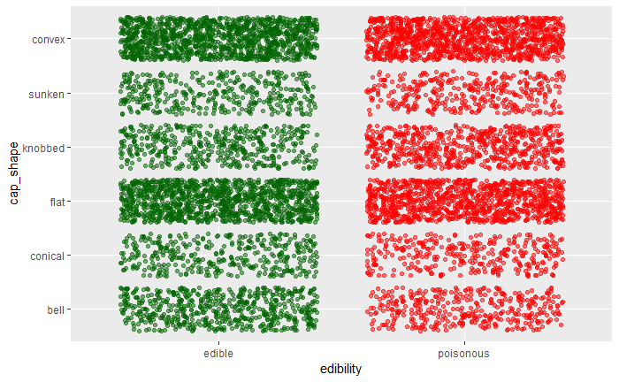

```r
ggplot(setas, aes(x = edibility, y = cap_shape, col = edibility,)) +
  geom_jitter(alpha = 0.5) +
  scale_color_manual(breaks = c("edible", "poisonous"),
                     values = c("dark green", "red") ) + theme(legend.position = "none")
```

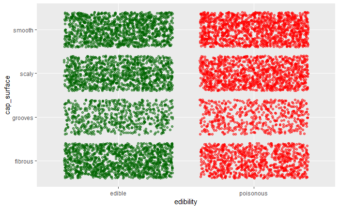

```r
ggplot(setas, aes(x = edibility, y = cap_surface, col = edibility,)) +
  geom_jitter(alpha = 0.5) +
  scale_color_manual(breaks = c("edible", "poisonous"),
                     values = c("dark green", "red") ) + theme(legend.position = "none")
```

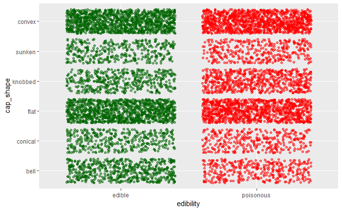

```r
ggplot(setas, aes(x = edibility, y = cap_shape, col = edibility,)) +
  geom_jitter(alpha = 0.5) +
  scale_color_manual(breaks = c("edible", "poisonous"),
                     values = c("dark green", "red") ) + theme(legend.position = "none")
```

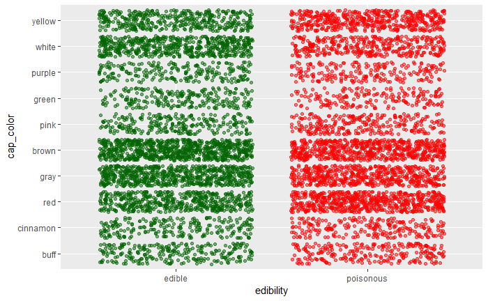

```r
ggplot(setas, aes(x = edibility, y = cap_color, col = edibility,)) +
  geom_jitter(alpha = 0.5) +
  scale_color_manual(breaks = c("edible", "poisonous"),
                     values = c("dark green", "red") ) + theme(legend.position = "none")
```

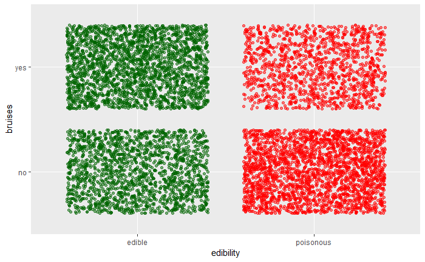

```r
ggplot(setas, aes(x = edibility, y = bruises, col = edibility,)) +
  geom_jitter(alpha = 0.5) +
  scale_color_manual(breaks = c("edible", "poisonous"),
                     values = c("dark green", "red") ) + theme(legend.position = "none")
```

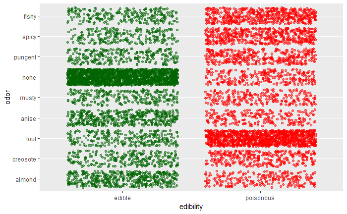

```r
ggplot(setas, aes(x = edibility, y = odor, col = edibility,)) +
  geom_jitter(alpha = 0.5) +
  scale_color_manual(breaks = c("edible", "poisonous"),
                     values = c("dark green", "red") ) + theme(legend.position = "none")
```